# Peaksat Read Depth Estimation

Cong Gao

11/04/2022

## 0.1 Introduction

*peaksat* is an R package to do Peak Saturation processing and analysis. Peak Saturation consists of iteratively sub-sampling ChIP-seq bam files and repeatedly calling peaks to detect at what read depth the peak call hits a point of diminishing returns, i.e. it has reached saturation.

Peak Saturation is a part of the quality control process and is useful for determining the potential benifit of deeper sequencing for improving peak calls. When libraries are too shallow, only a semi-random subset of peaks are called. This package provides methods for randomly subsetting bam files at fixed depth intervals and calling peaks via macs2 on each. As a result we can produce a curve of peak count vs read count and (with enough reads) estimate the total number of peaks that are potentially callable in each sequencing library. This also allows us to determine that either the library has reached saturation or roughly estimate how many reads would be required to reach saturation.

It requires an existing installation of macs2, which can be on your PATH or specified explicitly when calling submit_peaksat_jobs() or via the PS_MACS2_PATH option.

*peaksat* has primarily been tested using SGE (Sun Grid Engine) for job scheduling. It also has support for SLURM and even bash processing if neither job scheduler is available.

This is an R markdown file to show how to run peaksat pipeline, we’ll only focus on H4K5ac as an example.

## 0.2 Installation

Before starting, we’ll make sure peaksat is installed and loaded.

```r
#since peaksat is only available via github at the moment, devtools is required for installation
if(!require("devtools")) install.packages("devtools")
if(!require("peaksat")) devtools::install_github("FrietzeLabUVM/peaksat")

#These are just required for this markdown. There's a good chance you have them already.
if(!require("magrittr")) install.packages("magrittr")
if(!require("tidyverse")) install.packages("tidyverse")
if(!require("DT")) install.packages("DT")
```

```r
library(peaksat)
library(magrittr)
library(tidyverse)
```

*peaksat* consists of 2 steps :

A slow step 1 in which bam files are subsampled and then those subsasmples are used by macs2 for a peak call.

Step 2 is much faster and consists of plot generation and extrapolation.

## 0.3 Step 1

### 0.3.1 Locate Bam Files

Prior to running peaksat, we need a vector of file paths to relevant bam files. These bam files will be interatively subset and then used to run macs2 callpeak.

```r
#locate files
bam_files = dir("/slipstream/home/conggao/ChIP_seq/MCF10_H4Kac/", full.names = TRUE, pattern = "(H4K5ac|input).+rep.+bam$")
bam_files = bam_files[file.exists(bam_files)]
```

### 0.3.2 Match Input Files to ChIP-seq

If we want to use the appropriate input read file when calling MACS2, we need to match them to the ChIPseq file. In this case we want to match based on the cell line.

```r
df = data.frame(file = bam_files)
#parse out cell, mark, and rep information
df$name = df$file %>% basename %>% sub(".Align.+", "", .)
df = df %>%
  separate(col = "name",
           sep = "_",
           into = c("cell", "mark", "rep"),
           remove = FALSE)

df$cell %>% table
```

```
## .
##    MCF10A  MCF10AT1 MCF10CA1a MCF10DCIS
##         3         3         3         3
```

```r
df.by_mark = split(df, df$mark)

df_inputs = df.by_mark$input
df_inputs = rename(df_inputs, input_file = file)
df_inputs = select(df_inputs, input_file, cell)

mark_grouped = df.by_mark
mark_grouped$input = NULL

#use merge to match
todo = lapply(mark_grouped, function(mark_dt){
  merge(mark_dt, df_inputs, by = "cell")
})
```

### 0.3.3 Submit Jobs

Prior to submission, we need to create a peaksat_config object. This same object can be used for multiple submissions and ensures uniformity and should catch most invalid inputs.

```r
psc = peaksat_config(out_dir = "MCF10_H4Kac_Nov2022/",
                     stat_value = .01,
                     stat = "qValue",
                     is_PE = FALSE,
                     job_scheduler = "SGE")
class(psc)
```

```
## [1] "peaksat_config"
## attr(,"package")
## [1] "peaksat"
```

```r
ps_jobs = lapply(todo, function(td){
  submit_peaksat_jobs(psc = psc, treat_bams = td$file, ctrl_bams = td$input_file, await_completion = FALSE)
})
names(ps_jobs) = NULL
ps_jobs = unlist(ps_jobs)
watch_jids(ps_jobs)
```

watch_jids is useful for pausing a script until step 1 jobs have completely finished.

In this case we’ll see something like:

```
## [1] "pending jobs: 80......"
```

## 0.4 Step 2

### 0.4.1 Loading Peak Counts

After step 1 has finished, we use the same peaksat_config object to load all peak counts.

You can adjust min_signalValue. MACS2’s signalValue statistic is fold-enrichment and you should think about peak saturation in terms of what level of fold-enrichment you consider biologically relevant and worthwhile. You will need many more reads to consistently call peaks that are lower fold-enrichment, meaning a dataset will reach saturation at fewer reads if you consider a more stringent level of fold-enrichment.

```r
cnt_df = load_counts(psc, min_signalValue = 5)
```

If we parse out relevant sample info we can use this information to make nicer plots.

```r
cnt_df$sample = cnt_df$sample %>% sub(".Align.+", "", .)
cnt_df = cnt_df %>%
  separate(col = "sample",
           sep = "_",
           into = c("cell", "mark", "rep"),
           remove = FALSE)
cnt_df$sample = gsub("_", "\n", cnt_df$sample)
```

### 0.4.2 Plot Peak Saturation Curves

For relatively few samples we can look at all curves in one plot.

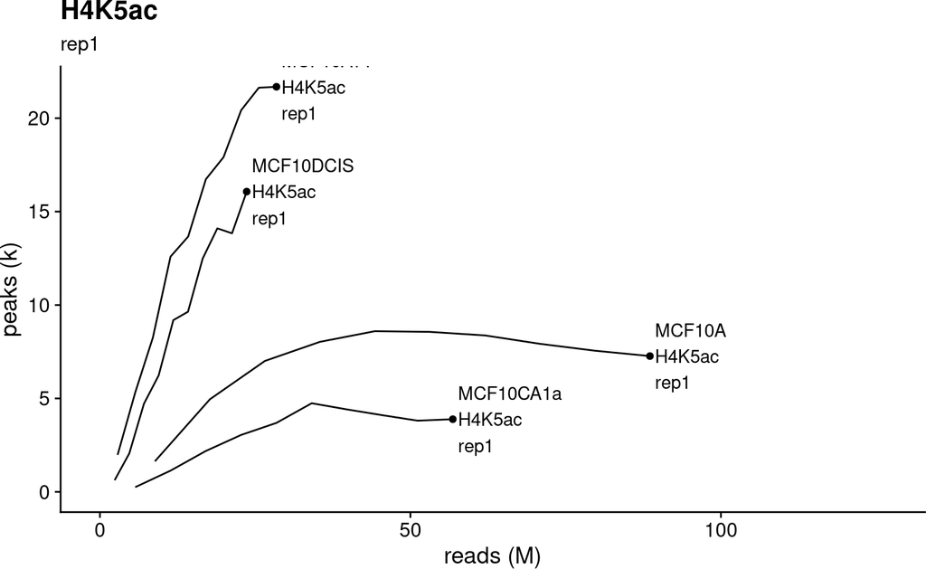

```r
m = "H4K5ac"
plot_peak_saturation_lines(subset(cnt_df, mark == m & rep == "rep1")) +
  labs(title = m, subtitle = "rep1")
```

However, this rapidly gets difficult to interpret as we increase the number of samples.

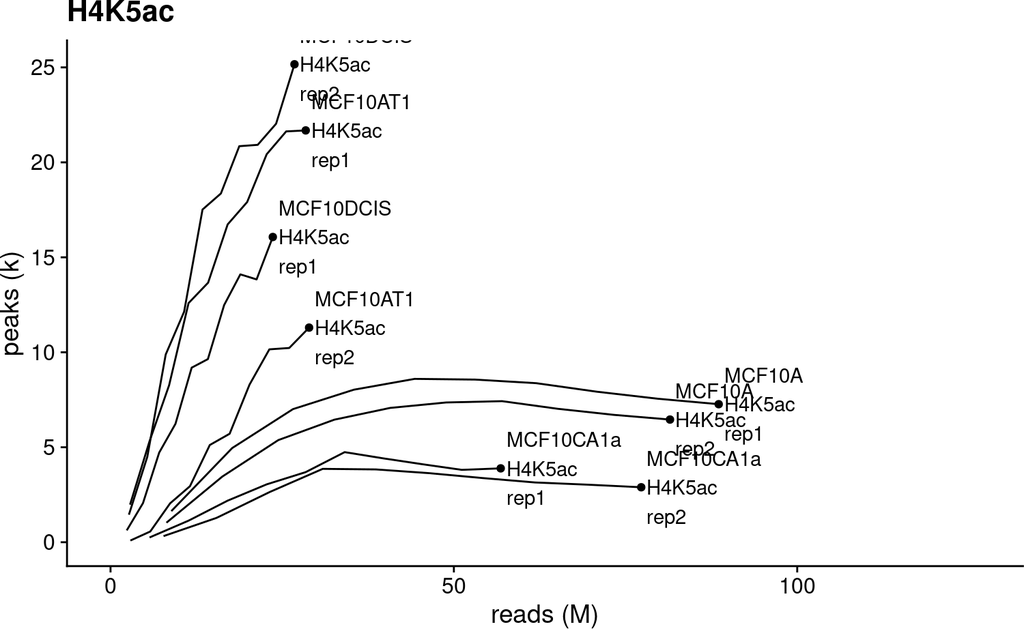

```r
plot_peak_saturation_lines(subset(cnt_df, mark == m)) +
  labs(title = m)
```

Using an alternative plotting method we can facet the data to split it up to be better understood.

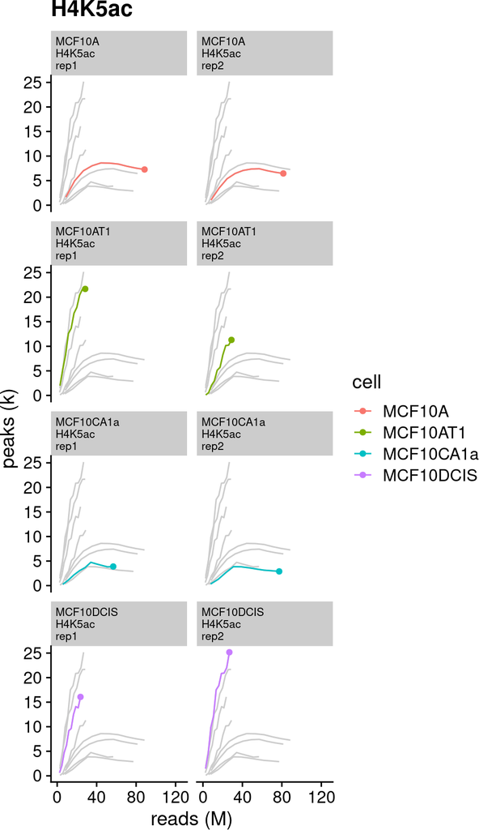

```r
plot_peak_saturation_lines.facetted(subset(cnt_df, mark == m), color_by = "cell") +
  facet_wrap(~sample, ncol = 2)+
  theme(strip.text.x = element_text(hjust = 0)) +
  labs(title = m)
```

### 0.4.3 Estimation by Linear Regression

For curves that have not reached saturation, linear regression does a good job extrapolating the number of reads required to reach saturation.

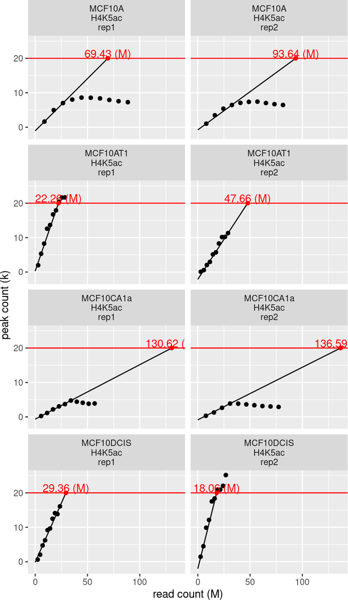

```r
est_lin_res = estimate_depth.linear(subset(cnt_df, mark == m), target_peaks = 20e3, max_read_count = 35e6, min_read_count = 5e6)
est_lin_res$plots +
  facet_wrap(~sample, ncol = 2)
```

```r
est_df = est_lin_res$estimates
est_df$needed_read_count = (est_df$saturation_read_count - est_df$current_read_count)/1e6
est_df = est_df[order(est_df$sample),]
DT::datatable(est_df[, c("sample", "needed_read_count")])
```

|  | sample | needed_read_count |
| --- | --- | --- |
| 1 | MCF10A H4K5ac rep1 | 42.8570176595903 |
| 2 | MCF10A H4K5ac rep2 | 61.0624542792328 |
| 3 | MCF10AT1 H4K5ac rep1 | -0.48105657958157 |
| 4 | MCF10AT1 H4K5ac rep2 | 18.7485782381219 |
| 5 | MCF10CA1a H4K5ac rep1 | 96.5228856265865 |
| 6 | MCF10CA1a H4K5ac rep2 | 105.688137322881 |
| 7 | MCF10DCIS H4K5ac rep1 | 5.72841772667196 |
| 8 | MCF10DCIS H4K5ac rep2 | -0.69708800678733 |

MCF10AT1 rep1 is basically at saturation while rep2 could benefit from about 19M reads.

For MCF10DCIS, rep2 is past saturation and rep1 needs only about 6M reads to reach it.